# R для тервера и матстата генерируем случайности

[figure not shown]

## Моё фото (если вы вдруг не знали как я выгяляжу)

[figure not shown]

## Чем будем заниматься

- Посмотрим на то, что уже заботали на тервере и матстате под новым углом
- Немного углубим знания, выработаем интуицию
- Будем смотреть презы, писать код, болтать, решать задачки на доске
- Посмотрим на примеры задач, которые приходится решать аналитикам

## В чём будем заниматься

- Конечно же в R
- R очень лёгок в освоении
- Одна из самыз красивых визуализаций данных
- Очень хорош в работе со статистикой
- Много готовых пакетов и большое комьюнити
- Используется многими компаниями в работе, вот устаревший [мини-список](https://blog.revolutionanalytics.com/2014/05/companies-using-r-in-2014.html)

## Чему мы хотим научиться

- Увидеть картину мира целиком, а не отдельные её части
- Чётко осознавать какие именно методы из статистики можно применить к задаче
- Понимать что за задача перед нами стоит и уметь переводить её на язык математики
- Использовать всю мощь R для этих целей

## Про активности

- Не делаешь сам $\Rightarrow$ никогда не научишься $\Rightarrow$ $3$ большие огромные домашки, за каждую можно набрать больше $100$ баллов
- Домашки делаются в командах по три человека
- Баллы ставятся на команду
- Для зачёта и оценки $10$ надо набрать на команду $100$ баллов
- В каждой домашке много рыбёшек и большой кит, можно решать только то, к чему лежит душа

## Регистрация команд

- Нужно разбиться на команды по три человека и [зарегистрироваться в форме](https://docs.google.com/forms/d/e/1FAIpQLSfW1e5wSWF42xlYxjE-XpXusxd7BMKROrdaiz2lPPio_OPsqw/viewform)
- Название своей команды нужно держать в тайне, у нас анонимное состязание, потому что есть супер-приз

## Суперприз

- Две команды, набравшие наибольшее количество баллов свожу почилить с пиццей и настолками на крышу Яндекса
- Команда может претендовать на крышу, если она набрала больше $100$ баллов

[figure not shown]

## Страничка курса со всей инфой:

> https://github.com/FUlyankin/r_probability

# Показать как сдавать домашки!

- **Опасность:** не смочь собрать в R домашку
- **Лечение:** написать мне и попросить помочь, я всегда отвечу
- В команде вас трое, а файл на всех один: разделение труда. Кто-то решает, кто-то вбивает.
- [Видео с запуском R и созданием pdf с домашкой](https://yadi.sk/i/Pxp_pByP6Em9-A)

[figure not shown]

# 1. Зачем мы учили тервер?

## Теория вероятностей

- Мы изучали вероятности
- Мы изучали события
- Мы изучали случайные величины и их распределения
- **ЗАЧЕМ МЫ ЭТО ДЕЛАЛИ?**

## Случайные ли величины?

[figure not shown]

## Демон Лапласа

[figure not shown]

## Байесовский взгляд на вероятность

- Лаплас: детерминизм, мы могли бы идеально прогнозировать вселенную, если бы измерили точное положение каждого атома. Издержки этого огромны.
- Между совершенством природы и несовершенством человеческого познания огромный разрыв.
- Неопределённость — результат этого разрыва. Случайность — это результат нашего невежества, а вероятность способ это невежество измерить.

## Частотный взгляд на вероятность

- Наука не может рассматривать вероятность как субъективную меру невежества.
- Можно оценивать вероятности только тех событий, которые происходят более одного раза.
- Вопрос «Какова вероятность, что кандидат N победит на выборах?» не имеет ответа, так как событие уникально и не обладает «частотой».

## Что мы имеем

[figure not shown]

- Сундук — различные процесс порождения данных. Теория вероятностей изучает этот сундук. В реальности мы его не видим.
- В реальном мире мы видим выборки, которые сундук выплёвывает на нас. Математическая статистика изучает испражнения сундука и по ним пытается восстановить его внутренности.

## Хлам из сундука

[figure not shown]

## Чем плюётся сундук

- Выборки, по которым можно попробовать восстановить его внутренности

[figure not shown]

## Базовые теоремы

- Все манипуляции по восстановлению внутренностей сундука по его испражнениям позволяет делать ряд теорем.
- Некоторые из них вы уже выучили!
- **Что это за теоремы?**

# 2. Закон больших чисел

## Закон больших чисел

- ЗБЧ утверждает, что среднее арифметическое большого числа похожих случайных величин «стабилизируется» с рочтом их числа
- Как бы сильно случайные величины не отклонялись от своего среднего значения, эти отклонения взаимно гасятся и среднее арифметическое приближается к постоянной величине

$$ \frac{X_1 + \ldots + X_n}{n} - \frac{E(X_1) + \ldots + E(X_n)}{n} \overset{p}{\to} 0 $$

- ЗБЧ сформулировано довольно много: Чебышёва,Хинчина и тд

## Закон больших чисел

[figure not shown]

## Вопрос про больницы

- Есть две больницы: маленькая и большая

[figure not shown]

- В обеих принимают роды, выяснилось, что в одной из больниц оценка вероятности появления мальчика составила $0.7$
- В какой из больниц это произошло и почему?

## Вопрос про больницы

Есть две больницы: маленькая и большая

[figure not shown]

- Скорее всего, это произошло в маленькой больнице. При малых объёмах выборки вероятность отклониться от $0.5$ больше. Именно это нашёптывает нам ЗБЧ.

### Слабая форма ЗБЧ (Пафнутий Львович Чебышёв)

Пусть $X_1, \ldots, X_n$ попарно независимые и одинаково распределённые случайные величины с конечным вторым моментом, $E(X_i^2) < \infty$, тогда имеет место сходимость:

$$ \frac{X_1 + \ldots + X_n}{n} \overset{p}{\to} E(X_1) $$

### Сильная форма ЗБЧ

Пусть $X_1, \ldots, X_n$ попарно независимые и одинаково распределённые случайные величины с конечным вторым моментом, $E(X_i^2) < \infty$, причём $\sum_{k=1}^{\infty} \frac{Var(X_k)}{k^2} < \infty$, тогда имеет место сходимость

$$ \frac{X_1 + \ldots + X_n}{n} \overset{п.н.}{\to} E(X_1) $$

## Страховые компании

- Примерно с $1600$-х годов ЗБЧ позволяет зарабатывать деньги на страховании
- **Упражнение:** для $25$-летней девушки вероятность прожить ещё год составляет $0.9$. Страховка в год стоить $1000$ рублей при взносе в $110$ рублей. Какой будет средняя прибыль компании с одной страховки?

## Страховые компании

$X_i$ — прибыль с одной страховки

| $X_i$ | $110$ | $-890$ |
| --- | --- | --- |
| $P(\ldots)$ | $0.9$ | $0.1$ |

Средняя прибыль компании составит $\frac{1}{n} \sum X_i$. По закону больших чисел:

$$ \frac{1}{n} \sum_{i=1}^n X_i \overset{p}{\to} E(X_1) = 0.9 \cdot 110 - 0.1 \cdot 890 = 10 $$

## Генерации разных штук

- Другой ништяк, который нам разрешает ЗБЧ — генерация случайных величин для оценки разных математических ожиданий и т.п.
- Не можешь посчитать? Сгенерируй!
- Обычно такие генерации называют методом Монте-Карло

## Метод Монте-Карло

- **Метод Монте-Карло** это общее название группы численных методов, основанных на получении большого числа реализаций случайного процесса, который формируется таким образом, чтобы его вероятностные характеристики совпадали с аналогичными величинами решаемой задачи

# 3. Генерации в R

## Генерации в R

Чтобы сварить в R любую случайную величину, нужно знать четыре буквы: $r$, $d$, $p$ и $q$.

- `rnorm` эта команда сгенерирует выборку из нормального распределения
- `dnorm` эта команда вычислит значение плотности в указанной точке
- `pnorm` эта команда находит вероятность
- `qnorm` эта команда находит квантили

## Генерируем нормальную выборку

Хочу сгенерировать нормальную случайную величину $X \sim N(\mu, \sigma^2)$:

$$ f(x) = \frac{1}{\sigma \sqrt{2 \pi}} \cdot e^{-\frac{(x - \mu)^2}{2 \sigma^2}} $$

```r
x <- rnorm(4, mean=5, sd=3)  # если дисперсия 9,
x                            # то стандартное отклонение 3
```

1. 3.44389035979933

2. 7.59097440961776

3. 3.6506566737062

4. 4.72979997241011

Хочу узнать $f(3)$

```r
dnorm(3, mean=5, sd=3)
```

0.106482668507451

Хочу узнать $F(3) = P(X < 3) = \int_{-\infty}^3 f(x)dx$

```r
pnorm(3, mean=5, sd=3)
```

0.252492537546923

Хочу узнать $P(4 < X < 9)$ - ?

Хочу узнать

$$P(4 < X < 9) = \int_4^9 f(x) dx = F(9) - F(4)$$

```r
pnorm(9, mean=5, sd=3) - pnorm(4, mean=5, sd=3)
```

0.539347440092368

Квантиль уровня $\gamma$ это такое число $q$, что:

$$ P(X < q) = \gamma $$

```r
qnorm(1 - 0.05/2, mean=0, sd=1)
```

1.95996398454005

```r
x <- c(0.95, 0.975, 0.995)
qnorm(x, mean = 0, sd = 1)
```

1. 1.64485362695147

2. 1.95996398454005

3. 2.5758293035489

```r
# квантили для другого распределения!
x <- c(0.95, 0.975, 0.995)
qt(x, df = 10)
```

1. 1.81246112281168

2. 2.22813885198627

3. 3.16927267261695

Что сгенерирует код?

```r
rnorm(10)
```

1. -0.707120663342578

2. -0.980011188525533

3. 0.396645732489923

4. -0.839942216948569

5. 1.75183863777376

6. 1.08577247385991

7. -0.396472256977632

8. -0.893778576611249

9. -0.274953778469149

10. -0.630480321588603

## Характеристики случайных величин

```r
x <- rnorm(1000, mean=5, sd=3)

mean(x) # среднее

var(x) # выборочная дисперсия

sd(x) # выборочное стандартное отклонение

median(x) # выборочная медиана
```

4.86203937386118

9.36098544923856

3.05957275599692

4.8395876699123

## Гистограмма

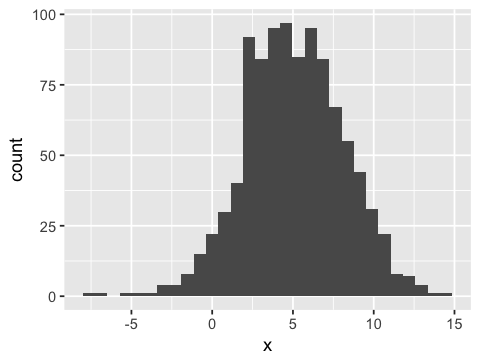

```r
library("ggplot2")  # пакет для красивых картинок

x <- rnorm(1000, mean=5, sd=3)

qplot(x) # гистограма
```

## Плотность распределения

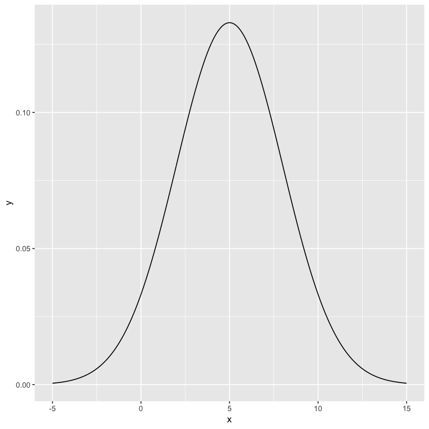

```r
library("ggplot2")  # пакет для красивых картинок

x <- seq(-5, 15, by=0.01)
y <- dnorm(x, mean=5, sd=3)

qplot(x, y, geom="line")
```

## Функция распределения

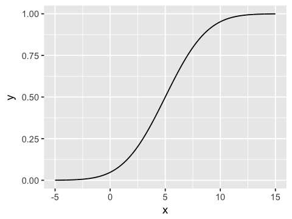

```r
library("ggplot2")  # пакет для красивых картинок

x <- seq(-5, 15, by=0.01)
y <- pnorm(x, mean=5, sd=3)

qplot(x, y, geom="line")
```

## Зачем всё это надо?!

- Чтобы решать реальные проблемы! Например, пусть $X \sim N(5,3)$. Как найти $E \left(\frac{1}{X} \right)$?
- Спосбо первый:

$$ E \left(\frac{1}{X} \right) = \int_{-\infty}^{+\infty} \frac{1}{x} \cdot \frac{1}{\sigma \sqrt{2 \pi}} \cdot e^{-\frac{(x - 5)^2}{2 \cdot 3^2}} dx $$

- Чтобы решать реальные проблемы! Например, пусть $X \sim N(5,3)$. Как найти $E \left(\frac{1}{X} \right)$?
- Спосбо второй (ЗБЧ разрешает нам так делать):

```r
n_obs <- 10^6 # число наблюдений

x <- rnorm(n_obs, mean = 5, sd = 3)

mean(1/x)
```

0.0767308182919124

## Зачем всё это надо?

- $X_1, X_2, X_3 \sim U[0;2]$, независимые
- Хотим знать $P(X_1 + X_2 + X_3^2 > 5)$

```r
n_obs <- 10^6
x_1 <- runif(n_obs, min = 0, max = 2)
x_2 <- runif(n_obs, min = 0, max = 2)
x_3 <- runif(n_obs, min = 0, max = 2)

success <- x_1 + x_2 + x_3^2 > 5
success[1:5]
sum(success) / n_obs
```

1. FALSE

2. FALSE

3. FALSE

4. FALSE

5. TRUE

0.147573

## Зачем всё это надо?

- $X_1, X_2, X_3 \sim U[0;2]$, независимые
- Хотим знать $$P(X_1 + X_2 > 0.8 \mid X_3 < 0.1)$$

```r
n_obs <- 10^6
x_1 <- runif(n_obs, min = 0, max = 2)
x_2 <- runif(n_obs, min = 0, max = 2)
x_3 <- runif(n_obs, min = 0, max = 2)

uslovie <- x_3 < 0.1
x_1[1:3]
uslovie[1:3]
x_1[uslovie][1:3]
```

1. 0.415671448688954

2. 0.721095726825297

3. 1.74133329978213

1. FALSE

2. FALSE

3. TRUE

1. 1.74133329978213

2. 1.82215116219595

3. 0.446165119297802

```r
n_obs <- 10^6
x_1 <- runif(n_obs, min = 0, max = 2)
x_2 <- runif(n_obs, min = 0, max = 2)
x_3 <- runif(n_obs, min = 0, max = 2)

uslovie <- x_3 < 0.1

success <- x_1[uslovie] + x_2[uslovie] > 0.8

sum(success)/n_obs
```

[output not shown]

## Генерация выборок

- С такой же лёгкостью можно генерировать любые выборки

```r
sample(1:10, size = 8)  # выборка без повторений
```

1. 4

2. 3

3. 6

4. 10

5. 5

6. 8

7. 1

8. 7

```r
sample(1:10, size = 8, replace = TRUE) # с повторениями
```

1. 8

2. 10

3. 3

4. 5

5. 6

6. 9

7. 9

8. 6

```r
# неправильная монетка
sample(c("Орёл", "Решка"), size = 5, replace = TRUE, prob = c(0.3, 0.7))
```

1. 'Решка'

2. 'Решка'

3. 'Решка'

4. 'Решка'

5. 'Решка'

## ЗБЧ и монетка

```r
x <-  sample(c("Орёл", "Решка"), size = 10^6, replace = TRUE, prob = c(0.3, 0.7))

sum(x == 'Орёл')/length(x)
```

0.299637

# 4. Центральная предельная теорема (ЦПТ)

## ЦПТ

- При определённых условиях сумма достаточно большого числа случайных величин имеет распределение близкое к нормальному
- **Главное:** чтобы случайные величины были похожи и не было такого, что одна резко выделяется на фоне остальных
- Есть много разных ЦПТ с разными условиями

## Классическая формулировка ЦПТ

Пусть $X_1, \ldots, X_n, \ldots$ — последовательность независимых одинаковых случайных велчин с конечным вторым моментом $E(X_i^2) < \infty$. Тогда

$$ \frac{(X_1 + \ldots + X_n) - n \cdot E(X_1)}{\sqrt{n \cdot Var(X_1)}} \overset{d}{\to} N(0,1) $$

## ЦПТ и равномерное распределение

- Пусть $X \sim U[-1;1]$, пусть $Y = X_1 + \ldots + X_n$

```r
n = 10^4
X1 <- runif(n, min = -1, max = 1)
X2 <- runif(n, min = -1, max = 1)
X3 <- runif(n, min = -1, max = 1)
X4 <- runif(n, min = -1, max = 1)
```

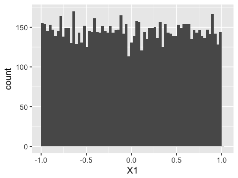

```r
qplot(X1, bins = 70)
```

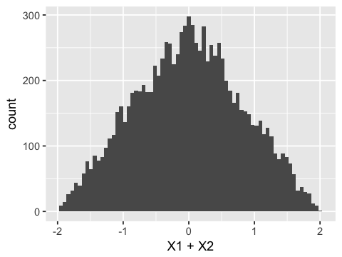

```r
qplot(X1 + X2, bins = 70)
```

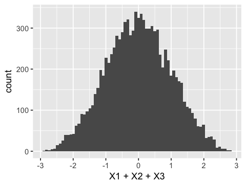

```r
qplot(X1 + X2 + X3, bins = 70)
```

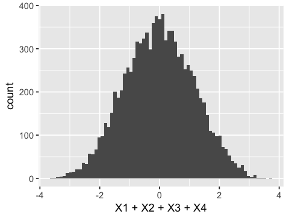

```r
qplot(X1 + X2 + X3 + X4, bins = 70)
```

## ЦПТ для равномерного

[figure not shown]

## ЦПТ для $\chi^2_1$

[figure not shown]

## Доска Гальтона

[figure not shown]

## ЦПТ на пальцевых пальцах

- $Y$ — время прихода Миши на первую пару
- На Мишу прыгнул кот и он проснулся пораньше, ускорение на $X_1$
- Пока готовил завтрак, убежало молоко, задержка на $X_2$
- Быстро приехал автобус, ускорение на $X_3$
- Встал в неожиданную пробку, задержка на $X_4$

## ЦПТ на пальцевых пальцах

[figure not shown]

- Ни одна из величин не выделяется!

## ЦПТ и ЗБЧ как скорости

В ЗБЧ:

$$ \frac{X_1 + \ldots + X_n - n E(X_1)}{n} \overset{p}{\to} 0 $$

В ЦПТ та же дробь домножается на $\sqrt{n}$, это замедляет сходимость и мы приходим к более интересному результату:

$$ \sqrt{n} \cdot \frac{X_1 + \ldots + X_n - n E(X_1)}{n} \overset{d}{\to} N(0, Var(X_1)) $$

## Крайнестан и среднестан

- ЦПТ и ЗБЧ работают в среднестане
- А что, если какая-то одна случайная величина выбивается?
- Тогда мы перемещаемся из среднестана в крайнестан и сталкиваемся с проблемой тяжёлых хвостов
- О тяжёлых хвостах мы ещё поговорим, они часто выскакивают в мире финансов

## Фальш в среднестане

[figure not shown]

## Фальш на выборах

[figure not shown]

## Фальш на выборах

[figure not shown]

# 5. Решаем вместе задачки на генерации

## 5.1 Камила, Вика и монетки

Две монеты, вероятности орла равны $0.6$ и $0.4$. Камила подбрасывает первую монетку до появления орла. Вика вторую.

**а)** Найдите с помощью симуляций вероятность того, что Вика сделает больше подбрасываний, чем Камила

**а)** Найдите с помощью симуляций вероятность того, что Вика сделает больше подбрасываний, чем Камила

```r
n_obs = 10^6
p1 = 0.6
p2 = 0.4
```

```r
# симулируем подбрасывания Вики и Камилы
x_kamila = rgeom(n_obs, prob = p1)
x_vika = rgeom(n_obs, prob = p2)

x_kamila[1:10]  # в векторе стоит число подбрасываний до первого орла
```

1. 0

2. 0

3. 0

4. 1

5. 0

6. 0

7. 0

8. 0

9. 2

10. 1

```r
sum(x_vika > x_kamila)/n_obs
```

0.473411

**б)** Камила сделает больше подбрасываний, чем Вика;

```r
n_obs = 10^6
p1 = 0.6
p2 = 0.4

# симулируем подбрасывания Вики и Камилы
x_kamila = rgeom(n_obs, prob = p1)
x_vika = rgeom(n_obs, prob = p2)

x_kamila[1:10]  # в векторе стоит число подбрасываний до первого орла
```

1. 0

2. 1

3. 2

4. 0

5. 0

6. 1

7. 0

8. 2

9. 0

10. 0

```r
sum(x_vika < x_kamila)/n_obs
```

0.210238

**в)** Камила и Вика сделают одинаковое число подбрасываний

```r
sum(x_vika == x_kamila)/n_obs
```

0.31644

**г)** Верно ли, что в сумме эти три вероятности дают единицу? Логично ли это?

```r
sum(x_vika > x_kamila)/n_obs + sum(x_vika < x_kamila)/n_obs + sum(x_vika == x_kamila)/n_obs
```

1

# 5.2 Человек и параход

Иван Фёдорович Крузенштерн (ШТО?!) случайным образом с возможностью повторов выбирает $10$ натуральных чисел от $1$ до $100$. Пусть $X$ — минимум из этих чисел, а $Y$ — максимум. С помощью симуляций оцените:

**а)** $P(Y > 3X)$

```r
natural <- sample(1:100, size = 5, replace = TRUE)
natural
```

1. 95

2. 37

3. 87

4. 49

5. 46

```r
min(natural)  # случайная величина X
max(natural)  # случайная величина Y
```

37

95

**а)** $P(Y > 3X)$

```r
n_obs = 10^6
x = rep(0, n_obs)
y = rep(0, n_obs)
```

```r
for(i in 1:n_obs){
    natural = sample(1:100, size = 10, replace = TRUE)  # сгенерировали выборку
    x[i] = min(natural)                                 # нашли минимум и максимум для неё
    y[i] = max(natural)
}
x[1:5]
```

1. 2

2. 3

3. 5

4. 13

5. 10

```r
success = y > 3*x
success[1:5]
```

1. TRUE

2. TRUE

3. TRUE

4. TRUE

5. TRUE

```r
sum(success) / n_obs
```

0.971832

**б)** $E(X \cdot Y)$

```r
mean(x*y)
```

884.453621

**в)** $P(Y > 3X \mid Y < X^2)$

```r
z <- c(1,2,3,4,5,6,7)
z > 4

z[z > 4]
```

1. FALSE

2. FALSE

3. FALSE

4. FALSE

5. TRUE

6. TRUE

7. TRUE

1. 5

2. 6

3. 7

```r
usl = y < x^2
usl[1:5]
```

1. FALSE

2. FALSE

3. FALSE

4. TRUE

5. TRUE

```r
success <- y[usl] > 3*x[usl]
sum(success) / sum(usl)
```

0.928028473824471

**г)** $E(X \cdot Y \mid Y < X^2)$

```r
mean(x[usl]*y[usl])
```

1636.77765428219

**д)** $E \left( \frac{X}{X + 2Y} \right)$

```r
z = x/(x + 2*y)
mean(z)
```

0.0482978237199387

**е)** $Corr(X,Y)$

```r
cor(x,y)
```

0.0986460764318367

# 5.3 Call me maybe

Известно, что в пятизначном номере телефона все цифры разные. Какова вероятность того, что при этом условии среди них только одна цифра чётная (номер может начинаться с нуля)?

```r
# генерируем номер телефона
sample(size = 5, 0:9, replace = FALSE)
```

1. 5

2. 7

3. 8

4. 6

5. 3

```r
# проверяем все цифры на чётность
sample(size = 5, 0:9, replace = FALSE) %% 2
```

1. 0

2. 0

3. 0

4. 1

5. 1

```r
# смотрим сколько в сумме нечётных цифр
sum(sample(size = 5, 0:9, replace = FALSE) %% 2)
```

2

```r
# и всё это в цикле!
n_obs = 10^6

m = 0
for( i in 1:n_obs){
    # если 4 нечётные, значит одна чётная
    if(sum(sample(size = 5, 0:9, replace = FALSE) %% 2) == 4){
        m = m + 1
    }
}

m/n_obs
```

0.099513

# 5.4 О спорт, ты — мир

Для $20$ участников соревнований, среди которых $8$ российских, в гостинице забронировано $20$ номеров. Из них $12$ с видом на море. Участники соревнований наугад получают ключи от номернов. Найдите вероятность того, что номера с видом на море достанутся всем российским спортсменам.

```r
# вектор номеров
room = c(rep('море',12),rep('пустошь',8))
room[1:5]
```

1. 'море'

2. 'море'

3. 'море'

4. 'море'

5. 'море'

```r
sample(room)[1:5] # перемешаем номера
```

1. 'пустошь'

2. 'пустошь'

3. 'море'

4. 'море'

5. 'море'

```r
# Будем считать что первые 8 позиций вектора относятся к россиянам
sample(room)[1:8] == 'море'
```

1. FALSE

2. TRUE

3. FALSE

4. FALSE

5. FALSE

6. TRUE

7. TRUE

8. FALSE

```r
n_obs = 10^6

# комнаты
room = c(rep('море',12),rep('пустошь',8))

m = 0
for(i in 1:n_obs){
    if(sum(sample(room)[1:8] == 'море') == 8){
        m = m + 1
    }
}

m/n_obs
```

0.003901

# 5.5 Ещё не успели забыть ЗБЧ?

- В начале пары мы смотрели такую картинку, давайте нарисуем её сами!

[figure not shown]

Игральная кость. Нам хочется узнать какое среднее значение на ней будет выпадать при увеличении количества бросков.

```r
sample(1:6, size = 1, replace = TRUE)

sample(1:6, size = 2, replace = TRUE)

sample(1:6, size = 3, replace = TRUE)

sample(1:6, size = 4, replace = TRUE)
```

2

1. 5

2. 3

1. 4

2. 3

3. 4

1. 2

2. 6

3. 1

4. 2

```r
n_obs = 500
kubik = rep(0, n_obs)

for(n in 1:n_obs){ # n - количество подбрасываний кубика

    # Сделали выборку
    smpl = sample(1:6, size = n, replace = TRUE)

    # Подсчитали среднее значение и запомнили его
    kubik[n] = mean(smpl)
}

kubik[1:5]
```

1. 4

2. 6

3. 3.66666666666667

4. 3.5

5. 4.2

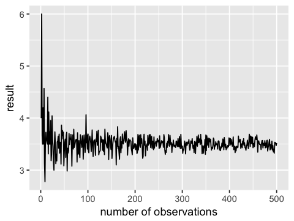

```r
qplot(1:n_obs, kubik, geom='line', xlab='number of observations', ylab='result')
```

```r
df = data.frame(n = 1:n_obs, kubik = kubik, mean = rep(3.5,n_obs))
head(df,2)
```

| n | kubik | mean |
| --- | --- | --- |
| 1 | 4 | 3.5 |
| 2 | 6 | 3.5 |

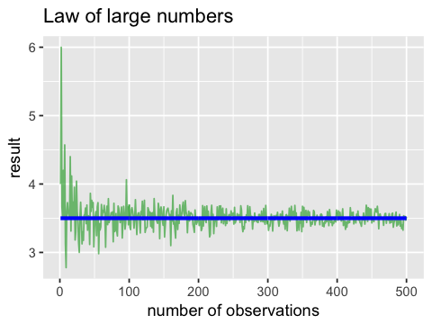

```r
# https://colorscheme.ru/color-converter.html
ggplot(df, aes(n)) +
  geom_line(aes(y=kubik), color="#0aa120", alpha = 0.6) +
  geom_line(aes(y=mean), color="blue",size=1.2) +
  xlab('number of observations') + ylab('result') +
  ggtitle('Law of large numbers')
```

# 5.6 Миша продаёт газеты

## Миша и газетный бизнес

**Смешная предыстория, которая не влезла на слайд.**

Покупать газету Миша решил по $15$ рублей, а продавать за $30$. Количество потенциальных покупателей - случайная величина с распределением Пуассона. Опытным путём было установлено, что среднее значение этой величины равно $50$. Нераспроданные газеты ничего не стоят. Пусть $n$- количество газет, максимизирующее ожидаемую прибыль Мишы.

С помощью компьютера найдите оптимальное значение $n$ и ожидаемую прибыль.

## Стохастическая прибыль

$$ \Pi = 30 \cdot X - 15 \cdot n \to \max_{n} $$

```r
n_obs = 10^6  # число наблюдений

cost = 15   # издержки на покупку газеты
price = 30  # цена, по которой будем продавать газету

x = rpois(n_obs, lambda = 50)  # среднее значение совпадает с lambda
x[1:5]

profit = x*price - 20*cost
profit[1:5]

# найдём среднюю прибыль
mean(profit)
```

1. 51

2. 40

3. 35

4. 62

5. 53

1. 1230

2. 900

3. 750

4. 1560

5. 1290

1199.89653

```r
n_obs = 10^6  # число наблюдений

profits = rep(0,100) # будем записывать средние прибыли
for(s in 1:100){
    x = rpois(n_obs, lambda = 50)  # генерируем покупочки

    x[x > s] = s  # нельзя продать лишнее

    profits[s] = mean(x*price - s*cost)  # запоминем среднюю прибыль
}
```

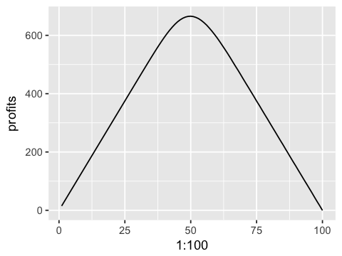

```r
qplot(1:100, profits, geom='line')
```

```r
max(profits)
which.max(profits)
```

665.65521

50

```r
sqrt(var(profits))
```

207.004054023229

## Дисперсия прибыли

```r
n_obs = 10^6  # число наблюдений

profits = rep(0,100)    # будем записывать средние прибыли
std_error = rep(0,100)  # сюда будем записыват ошибку
for(s in 1:100){
    x = rpois(n_obs, lambda = 50)  # генерируем покупочки

    x[x > s] = s  # нельзя продать лишнее
    profits[s] = mean(x*price - s*cost)         # запоминем среднюю прибыль
    std_error[s] = sqrt(var(x*price - s*cost))  # запоминаем дисперсию
}
```

```r
df = data.frame(s = 1:100, profit = profits, std_error = std_error)
head(df,2)
```

| s | profit | std_error |
| --- | --- | --- |
| 1 | 15 | 0 |
| 2 | 30 | 0 |

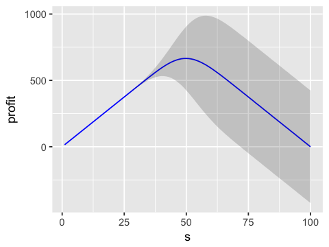

```r
ggplot(df, aes(s)) +
  geom_line(aes(y=profit), colour="blue") +
  geom_ribbon(aes(ymin = profit - 2*std_error,
                  ymax = profit + 2*std_error), alpha=0.2)
```

## 5.7 Зёрна

```r
set.seed(42)
rnorm(1, mean = 2, sd = 3)
```

6.11287534144001

```r
rnorm(1, mean = 2, sd = 3)
```

# 6. Случайные величины бывают очень разными

- Как бы вы замоделировали подбрасывание монетки?

\begin{equation} \begin{aligned} & X \sim Bern(p) \\ & E(x) = p \\ & Var(X) = p \cdot (1-p) \end{aligned} \end{equation}

- Как бы вы замоделировали число попаданий в баскетбольную корзину?

\begin{equation} \begin{aligned} & X_i \sim Bern(p) \\ & Y = X_1 + \ldots + X_n \quad \Rightarrow \quad Y \sim Bin(p,n)\\ & P(Y = k) = C_n^k \cdot p^k \cdot (1-p)^{n-k} \\ & E(x) = n \cdot p \\ & Var(X) = n \cdot p \cdot (1-p) \end{aligned} \end{equation}

- Биномиальное распределение используется для моделирования числа успехов в серии из $n$ испытаний

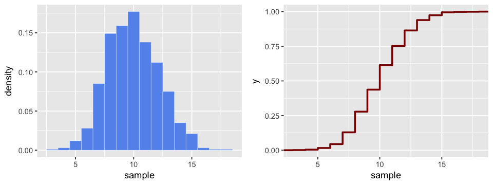

```r
n = 1000
size = 20
p = 0.5

x <- rbinom(n, size = size, prob = p)
picture(x)
```

- Число людей в очереди

[figure not shown]

\begin{equation} \begin{aligned} & X \sim Poiss(\lambda) \\ & P(X = k) = \frac{\lambda^k \cdot e^{-\lambda}}{k!} \\ & E(x) = Var(X) = \lambda \\ \end{aligned} \end{equation}

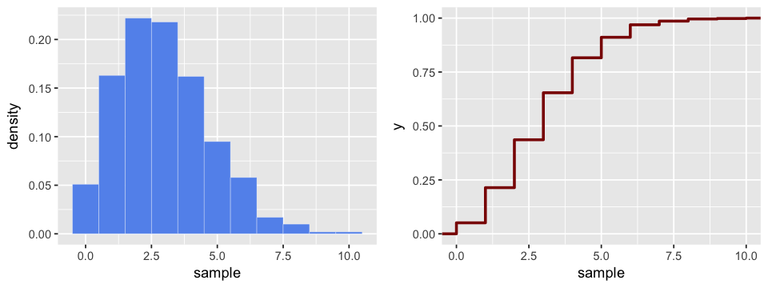

```r
n = 1000

# Распределение Пуассона, Pois(lambda)
lambda =3
x <- rpois(n, lambda = lambda)

picture(x)
```

- Распределение Пуассона часто используется для моделирования "событий-счётчиков", при этом $\lambda$ это интенсивность потока событий.
- Если у нас ест несколько суммирующихся между собой потоков, их интенсивности суммируются. То есть, если

$$ X_1, \ldots, X_k \sim Poiss(\lambda_i) \quad \Rightarrow \quad X_1 + \ldots + X_k \sim Poiss(\lambda_1 + \ldots + \lambda_k) $$

- Точное время прихода Миши на первую пару

[figure not shown]

- Погрешность весов

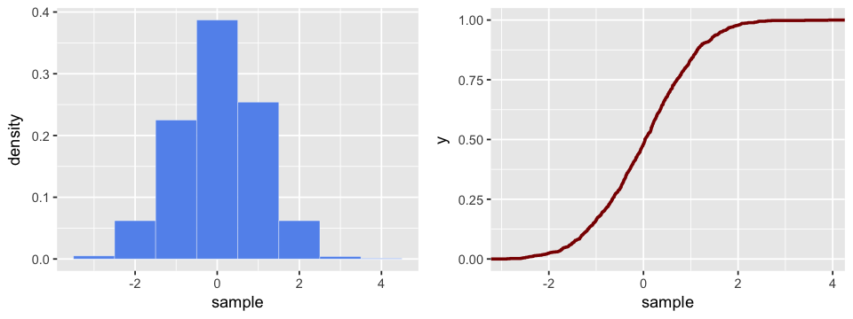

```r
n = 1000

# Нормальное распределение, N(mu, sigma)
mu = 0;  sigma = 1
x <- rnorm(n, mean = mu, sd = sigma)
picture(x)
```

- Время до поломки станка, время до смерти, любое время между событиями в потоке

[figure not shown]

\begin{equation} \begin{aligned} & X \sim Exp(\alpha) &f(x) = \alpha \cdot e^{-\alpha x} \\ & E(x)= \frac{1}{\alpha} &Var(X) = \frac{1}{\alpha^2} \end{aligned} \end{equation}

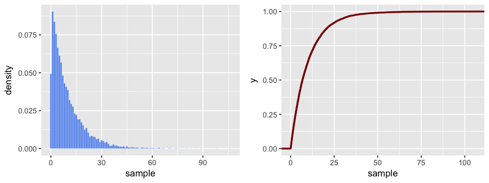

```r
n = 10000

# Экспоненциальное распределение, Exp(alpha)
alpha = 0.1

x <- rexp(n, rate = alpha)
picture(x)
```

- У экспоненциального распределения нет памяти, то есть если $X \sim Exp(\alpha)$, тогда $P(X > s+t \mid X \ge s) = P(X > t)$
- Пример: пусть автобусы приходят на остановку случайно, но с некоторой фиксированной средней интенсивностью. Тогда количество времени, уже затраченное пассажиром на ожидание автобуса, не влияет на время, которое ему ещё придётся прождать
- Время между потоком пуассоновских событий имеет экспоненциальное распределение
- $Exp(\frac{1}{2}) = \chi^2_2$
- Время, в которое в течение суток родится ребёнок

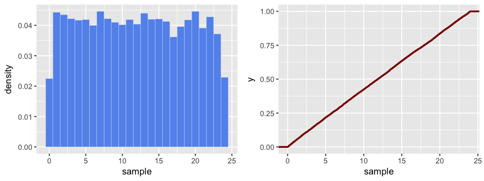

```r
# Равномерное распределение, U[mn;mx]
n = 10000
mn=0; mx=24

x <- runif(n, min = mn, max = mx)
picture(x)
```

## Взаимосвязи между распределениями

http://www.math.wm.edu/~leemis/2008amstat.pdf

# Что мы сделали?

- Поняли, что тервер и матстат помогают нам выразить наше невежество
- Вспомнили что такое ЗБЧ и ЦПТ и поговорили о том какие вещи они нам разрешают делать
- Поговорили о том как в R генерируются случайные величины и решили пару задачек
- Обсудили, что распределения бывают разными
- Поделились на команды
- Приступили к решению первой домашки